# Activity quality from activity monitors

Pablo Salvador

Thursday, June 11, 2015

This is a study to predict the manner in which six subjects perform the exercise by using data from accelerometers on the belt, forearm, arm, and dumbell of the participants. The data comes from “http://groupware.les.inf.puc-rio.br/har”.

For this purpose the data “https://d396qusza40orc.cloudfront.net/predmachlearn/pml-training.csv” has been read and several colums has been selected for the study. The selected colums are the variables related to the measured of the acelerometers, gyroscopes and magnetometers (along the x,y and z axes), named as:

```r
library(caret)
library(rpart)
library(randomForest)
setwd('F:/coursera/hopkinsUniversity/08-PracticalMachineLearning/project/')

datos<-read.table("pml-training.csv",sep=',',header=TRUE,na.strings=c("NA", "#DIV/0!"))

datos<-data.frame(datos[,8:11],datos[,37:49],datos[,60:68],datos[,84:86],datos[,115:124],datos[,151:160])
colnames(datos)
```

```
##  [1] "roll_belt"         "pitch_belt"        "yaw_belt"
##  [4] "total_accel_belt"  "gyros_belt_x"      "gyros_belt_y"
##  [7] "gyros_belt_z"      "accel_belt_x"      "accel_belt_y"
## [10] "accel_belt_z"      "magnet_belt_x"     "magnet_belt_y"
## [13] "magnet_belt_z"     "roll_arm"          "pitch_arm"
## [16] "yaw_arm"           "total_accel_arm"   "gyros_arm_x"
## [19] "gyros_arm_y"       "gyros_arm_z"       "accel_arm_x"
## [22] "accel_arm_y"       "accel_arm_z"       "magnet_arm_x"
## [25] "magnet_arm_y"      "magnet_arm_z"      "roll_dumbbell"
## [28] "pitch_dumbbell"    "yaw_dumbbell"      "gyros_dumbbell_z"
## [31] "accel_dumbbell_x"  "accel_dumbbell_y"  "accel_dumbbell_z"
## [34] "magnet_dumbbell_x" "magnet_dumbbell_y" "magnet_dumbbell_z"
## [37] "roll_forearm"      "pitch_forearm"     "yaw_forearm"
## [40] "gyros_forearm_x"   "gyros_forearm_y"   "gyros_forearm_z"
## [43] "accel_forearm_x"   "accel_forearm_y"   "accel_forearm_z"
## [46] "magnet_forearm_x"  "magnet_forearm_y"  "magnet_forearm_z"
## [49] "classe"
```

```r
inTrain<-createDataPartition(y=datos$classe,p=0.7,list=FALSE)
training<-datos[inTrain,]
testing<-datos[-inTrain,]
```

The first thing to do is divide the data into a training set and a test set, we select a 70% of the data for the training and 30% for the test. Once the data is divide, we start an exploratory analysis with the training dataset.

In the next plot we can see the correlation between those variables and the variable “class” that we want to predict.

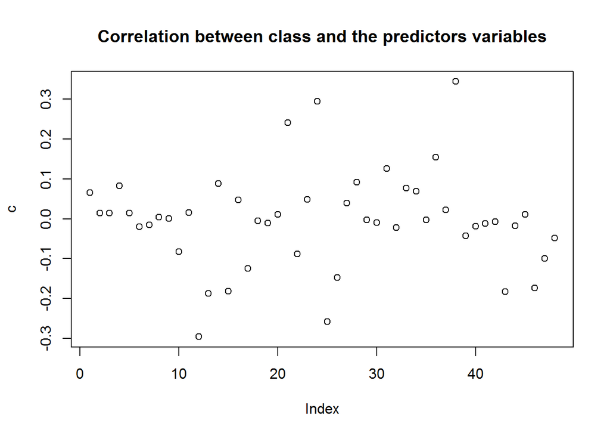

```r
c<-cor(training[1:48],as.numeric(training$classe))
plot(c,main="Correlation between class and the predictors variables")
```

The correlation is low for all the data. Now we are going to start to developed the learning algorithm. For this purpose we use the training data set and perform two kinds of machine learning algorithms “trees” and “random forest”. After that we run these models with the test dataset in order to analyze the results.

```r
set.seed(1234)
modelFitRpart<-train(classe ~ ., data=training,na.action=na.omit,method='rpart')
modelFitRfor<-train(classe ~ ., data=training,na.action=na.omit,method='rf')

predModelFitRpart<-predict(modelFitRpart,newdata=testing)
predModelFitRfor<-predict(modelFitRfor,newdata=testing)
```

In first place we plot the classification tree:

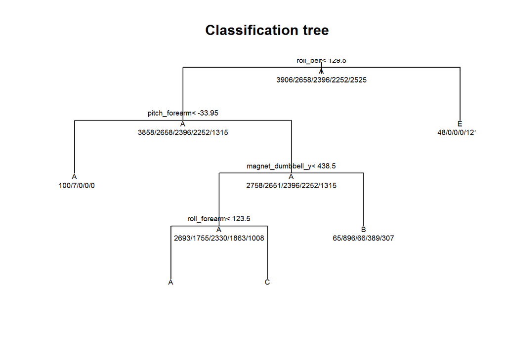

```r
plot(modelFitRpart$finalModel,uniform=TRUE,main="Classification tree")
text(modelFitRpart$finalModel,use.n=TRUE,all=TRUE,cex=0.6)
```

It works pretty fast, but the confusion matrix is not favourable:

```r
confusionMatrix(predModelFitRpart,testing$classe)
```

```
## Confusion Matrix and Statistics
##
##           Reference
## Prediction    A    B    C    D    E
##          A 1506  473  450  414  143
##          B   22  397   43  183  163
##          C  120  269  533  367  287
##          D    0    0    0    0    0
##          E   26    0    0    0  489
##
## Overall Statistics
##
##                Accuracy : 0.497
##                  95% CI : (0.4842, 0.5099)
##     No Information Rate : 0.2845
##     P-Value [Acc > NIR] : < 2.2e-16
##
##                   Kappa : 0.3437
##  Mcnemar's Test P-Value : NA
##
## Statistics by Class:
##
##                      Class: A Class: B Class: C Class: D Class: E
## Sensitivity            0.8996  0.34855  0.51949   0.0000  0.45194
## Specificity            0.6485  0.91340  0.78535   1.0000  0.99459
## Pos Pred Value         0.5044  0.49134  0.33820      NaN  0.94951
## Neg Pred Value         0.9420  0.85385  0.88559   0.8362  0.88957
## Prevalence             0.2845  0.19354  0.17434   0.1638  0.18386
## Detection Rate         0.2559  0.06746  0.09057   0.0000  0.08309
## Detection Prevalence   0.5074  0.13730  0.26780   0.0000  0.08751
## Balanced Accuracy      0.7741  0.63098  0.65242   0.5000  0.72326
```

But in the case of the random forest the result, looking at the confusion matrix are quite satisfactory:

```r
confusionMatrix(predModelFitRfor,testing$classe)
```

```
## Confusion Matrix and Statistics
##
##           Reference
## Prediction    A    B    C    D    E
##          A 1673    2    0    0    0
##          B    1 1134    5    0    0
##          C    0    3 1020   16    2
##          D    0    0    1  948    2
##          E    0    0    0    0 1078
##
## Overall Statistics
##
##                Accuracy : 0.9946
##                  95% CI : (0.9923, 0.9963)
##     No Information Rate : 0.2845
##     P-Value [Acc > NIR] : < 2.2e-16
##
##                   Kappa : 0.9931
##  Mcnemar's Test P-Value : NA
##
## Statistics by Class:
##
##                      Class: A Class: B Class: C Class: D Class: E
## Sensitivity            0.9994   0.9956   0.9942   0.9834   0.9963
## Specificity            0.9995   0.9987   0.9957   0.9994   1.0000
## Pos Pred Value         0.9988   0.9947   0.9798   0.9968   1.0000
## Neg Pred Value         0.9998   0.9989   0.9988   0.9968   0.9992
## Prevalence             0.2845   0.1935   0.1743   0.1638   0.1839
## Detection Rate         0.2843   0.1927   0.1733   0.1611   0.1832
## Detection Prevalence   0.2846   0.1937   0.1769   0.1616   0.1832
## Balanced Accuracy      0.9995   0.9972   0.9949   0.9914   0.9982
```

```r
datos2<-data.frame(datos$roll_belt,datos$pitch_forearm,datos$magnet_dumbbell_y,datos$roll_forearm,datos$classe)
inTrain2<-createDataPartition(y=datos2$datos.classe,p=0.7,list=FALSE)
training2<-datos[inTrain2,]
testing2<-datos[-inTrain2,]
modelFitRfor2<-train(classe ~ ., data=training2,na.action=na.omit,method='rf')
predModelFitRfor2<-predict(modelFitRfor2,newdata=testing2)
confusionMatrix(predModelFitRfor2,testing2$classe)
```

```
## Confusion Matrix and Statistics
##
##           Reference
## Prediction    A    B    C    D    E
##          A 1672    9    0    0    0
##          B    2 1127    4    0    0
##          C    0    3 1022   18    5
##          D    0    0    0  944    1
##          E    0    0    0    2 1076
##
## Overall Statistics
##
##                Accuracy : 0.9925
##                  95% CI : (0.99, 0.9946)
##     No Information Rate : 0.2845
##     P-Value [Acc > NIR] : < 2.2e-16
##
##                   Kappa : 0.9905
##  Mcnemar's Test P-Value : NA
##
## Statistics by Class:
##
##                      Class: A Class: B Class: C Class: D Class: E
## Sensitivity            0.9988   0.9895   0.9961   0.9793   0.9945
## Specificity            0.9979   0.9987   0.9946   0.9998   0.9996
## Pos Pred Value         0.9946   0.9947   0.9752   0.9989   0.9981
## Neg Pred Value         0.9995   0.9975   0.9992   0.9960   0.9988
## Prevalence             0.2845   0.1935   0.1743   0.1638   0.1839
## Detection Rate         0.2841   0.1915   0.1737   0.1604   0.1828
## Detection Prevalence   0.2856   0.1925   0.1781   0.1606   0.1832
## Balanced Accuracy      0.9983   0.9941   0.9954   0.9895   0.9970
```